# Sophia Okada Callahan

Mini Project Three: Analyzing CNN and Fox News Homepage Screen Captures from 2005–2024 INFO 230: Cultural Analytics, Tim Tangherlini

## Background:

Initially, I wanted to analyze the 600+ screenshots on my desktop, but then realized how boring that would be for you, Tim, to review. I was still interested in the idea of screenshots, as a habitual capture pattern that happens both in personal usage and on large scale, to essentially, save visual data for later. I thought of The Way Back Machine as a resource and how this is one of the sole public archives of the web. For the sake of this project, I chose CNN and Fox News homepage screenshots. If there was more time (and if images didn’t take so long to process) I would’ve also liked to have added The Guardian and the New York Times to understand how the aesthetics, hero images and web design, of news outlets converge and diverge from each other over the years.

## Research Question:

How has CNN and Fox News homepages changed over time? Have they grown closer together in design and home page images or have they grown farther apart? How has design shifted in relation to political moments?

## Method:

I asked Claude to assemble 50 random images of screenshots of the homepage of CNN & Fox News for every year that the Way Back Machine has been capturing. It initially said that it went back to the year 2000, but most of those images were broken links, or could not load, so this project analyzes from 2005-2024.

Using the notebook we used in class as a template for this notebook, Claude applied the ResNet-50 + UMAP + KMeans pipeline as a way to measure any latent visual structure that separates the two outlets and how has that structure changed over time.

## Dataset

**Preprocessing:** The Wayback Machine toolbar is suppressed using the `if_` URL modifier so screenshots show only the original page. Images are loaded with PIL and resized to 224×224 with ImageNet normalization for ResNet-50.

## Methods

1. **CDX API** — Wayback Machine's snapshot index, queried to list available captures per year per outlet, then randomly sampled
2. **Playwright** — headless Chromium browser captures a 1280×900 viewport screenshot of each archived URL
3. **ResNet-50 feature extraction** — 2,048-d feature vector per screenshot
4. **UMAP** — projects to 2-d, colored by outlet and by year to reveal temporal drift
5. **KMeans clustering** — groups screenshots by visual similarity
6. **Temporal analysis** — centroid distance between CNN and Fox in feature space, plotted year by year

## 0. Environment Setup

This notebook uses the `image-analysis` conda environment plus two additional packages. Run these once in your terminal:

```
conda activate image-analysis
pip install playwright requests
playwright install chromium
```

Then verify below:

```python
import os
os.environ["KMP_DUPLICATE_LIB_OK"] = "TRUE"

import torch
print(f"PyTorch:  {torch.__version__}")
print(f"MPS:      {hasattr(torch.backends, 'mps') and torch.backends.mps.is_available()}")

import requests
print(f"requests: OK")

from playwright.sync_api import sync_playwright
print(f"playwright: OK")
```

```
PyTorch:  2.11.0
MPS:      True
requests: OK
playwright: OK
```

## 1. Imports & Configuration

```python
import os
import json
import re
import time
import random
import warnings
warnings.filterwarnings('ignore')

import numpy as np
import pandas as pd
from pathlib import Path
from tqdm import tqdm

import requests

import matplotlib.pyplot as plt
import matplotlib.cm as cm
import seaborn as sns
import plotly.express as px
import plotly.graph_objects as go
import plotly.io as pio
pio.renderers.default = 'iframe'

import torch
import torchvision.models as models
import torchvision.transforms as transforms
from PIL import Image

pd.set_option('display.max_rows', 60)
pd.set_option('display.max_colwidth', 80)

# ── Device detection ─────────────────────────────────────────────────────────
if torch.cuda.is_available():
    DEVICE = torch.device('cuda')
    print(f'Using CUDA GPU: {torch.cuda.get_device_name(0)}')
elif hasattr(torch.backends, 'mps') and torch.backends.mps.is_available():
    DEVICE = torch.device('mps')
    print('Using Apple Silicon GPU (MPS)')
else:
    DEVICE = torch.device('cpu')
    print('Using CPU')

print(f'PyTorch {torch.__version__} | Device: {DEVICE}')
print('Imports OK')
```

```
Using Apple Silicon GPU (MPS)
PyTorch 2.11.0 | Device: mps
Imports OK
```

```python
# ── Config ────────────────────────────────────────────────────────────────────
OUTLETS = {
    'cnn':     'www.cnn.com',
    'foxnews': 'foxnews.com',    # no www — archive uses bare domain from ~2013
}
YEARS            = list(range(2005, 2025))   # 2005–2024
SAMPLES_PER_YEAR = 50                        # snapshots per outlet per year
RANDOM_SEED      = 42
REQUEST_DELAY    = 2.5                       # seconds between Wayback requests

SCREENSHOT_DIR = Path('./wayback_screenshots')
OUTPUT_DIR     = Path('./wayback_output')
MANIFEST_CSV   = OUTPUT_DIR / 'snapshot_manifest.csv'
FEATURE_CACHE  = OUTPUT_DIR / 'wayback_features.npz'

for d in [OUTPUT_DIR, SCREENSHOT_DIR]:
    d.mkdir(exist_ok=True)
for outlet in OUTLETS:
    (SCREENSHOT_DIR / outlet).mkdir(exist_ok=True)

random.seed(RANDOM_SEED)
print('Config OK')
```

```
Config OK
```

## 2. Dataset: CDX API Sampling

The Wayback Machine's CDX API lets us query all archived snapshots for a URL. We retrieve up to one snapshot per day per year (`collapse=timestamp:8`), then randomly sample 50.

The `if_` suffix on Wayback URLs suppresses the toolbar so screenshots show only the original page.

```python
CDX_ENDPOINT = 'http://web.archive.org/cdx/search/cdx'

def query_cdx(domain, year, max_results=500, retries=3):
    """Return a list of timestamp strings for the domain in the given year."""
    params = {
        'url':        f'http://{domain}/',
        'output':     'json',
        'fl':         'timestamp,statuscode',
        'filter':     ['statuscode:200'],
        'matchType':  'exact',
        'from':       f'{year}0101000000',
        'to':         f'{year}1231235959',
        'limit':      max_results,
        'collapse':   'timestamp:8',   # at most one per calendar day
    }
    for attempt in range(retries):
        try:
            resp = requests.get(CDX_ENDPOINT, params=params, timeout=45)
            resp.raise_for_status()
            data = resp.json()
            if len(data) <= 1:
                return []
            return [row[0] for row in data[1:]]
        except Exception as e:
            wait = 5 * (attempt + 1)
            print(f'  Attempt {attempt+1} failed ({e}), retrying in {wait}s...')
            time.sleep(wait)
    print(f'  Gave up on {domain} {year} after {retries} attempts')
    return []

def wayback_url(timestamp, domain):
    """Construct a toolbar-free Wayback URL."""
    return f'https://web.archive.org/web/{timestamp}if_/http://{domain}/'

print('CDX helpers defined')
```

```
CDX helpers defined
```

```python
# ── Build or load the snapshot manifest ───────────────────────────────────────
# Re-running this cell will fill in any year/outlet combinations that came back
# with 0 snapshots (e.g. due to timeouts) without re-querying successful ones.

if MANIFEST_CSV.exists():
    manifest = pd.read_csv(MANIFEST_CSV)
    print(f'Loaded existing manifest: {len(manifest)} snapshots')
else:
    manifest = pd.DataFrame()

# Find which outlet/year combos are missing or empty
existing = set()
if len(manifest) > 0:
    for _, row in manifest.iterrows():
        existing.add((row['outlet'], int(row['year'])))

missing = [
    (outlet, domain, year)
    for outlet, domain in OUTLETS.items()
    for year in YEARS
    if (outlet, year) not in existing
]

if missing:
    print(f'{len(missing)} outlet/year combinations to query...')
    new_records = []
    for outlet, domain, year in missing:
        print(f'  Querying {outlet} {year}...', end=' ', flush=True)
        timestamps = query_cdx(domain, year)
        sampled = random.sample(timestamps, min(SAMPLES_PER_YEAR, len(timestamps)))
        for ts in sampled:
            new_records.append({
                'outlet':      outlet,
                'domain':      domain,
                'year':        year,
                'month':       int(ts[4:6]),
                'timestamp':   ts,
                'wayback_url': wayback_url(ts, domain),
                'filename':    f'{outlet}_{ts}.png',
                'filepath':    str(SCREENSHOT_DIR / outlet / f'{outlet}_{ts}.png'),
            })
        print(f'{len(sampled)} snapshots')
        time.sleep(0.5)

    if new_records:
        manifest = pd.concat([manifest, pd.DataFrame(new_records)], ignore_index=True)
        manifest.to_csv(MANIFEST_CSV, index=False)
        print(f'Manifest updated: {len(manifest)} total snapshots')
else:
    print('Manifest complete — no missing combinations.')

print(f'\nSnapshots per outlet:')
print(manifest['outlet'].value_counts().to_string())
print(f'\nSnapshots per year (both outlets):')
print(manifest.groupby(['outlet','year']).size().unstack(fill_value=0).to_string())
```

```
Loaded existing manifest: 1395 snapshots
Manifest complete — no missing combinations.

Snapshots per outlet:
outlet
cnn        751
foxnews    644

Snapshots per year (both outlets):
year     2005  2006  2007  2008  2009  2010  2011  2012  2013  2014  2015  2016  2017  2018  2019  2020  2021  2022  2023  2024
outlet
cnn        42    39    39     8    12    49     1    50    28    45    50    49    50    50    50    45    45    39    39    21
foxnews    35    43    39    27    25    11    26    32    26    20    29    17    22    47    44    44    38    38    39    42
```

## 3. Screenshot Capture with Playwright

This cell opens a headless Chromium browser and screenshots each archived URL. It skips files that already exist, so it's safe to re-run if interrupted.

> **Expected time:** ~1.5–3 hours for ~2,000 screenshots (including the 2.5-second polite delay). Run it and come back — the `tqdm` bar shows progress. If you need to stop, just re-run the cell and it will pick up where it left off.

```python
import threading

to_capture = manifest[~manifest['filepath'].apply(os.path.exists)].copy()
already_done = len(manifest) - len(to_capture)
print(f'{already_done} already captured, {len(to_capture)} remaining')

failed = []

def run_capture():
    from playwright.sync_api import sync_playwright
    with sync_playwright() as p:
        browser = p.chromium.launch()
        context = browser.new_context(
            viewport={'width': 1280, 'height': 900},
            user_agent='Mozilla/5.0 (compatible; WaybackResearch/1.0)'
        )
        page = context.new_page()

        for _, row in tqdm(to_capture.iterrows(), total=len(to_capture), desc='Capturing'):
            fp = row['filepath']
            if os.path.exists(fp):
                continue
            os.makedirs(os.path.dirname(fp), exist_ok=True)
            try:
                page.goto(row['wayback_url'], timeout=45000, wait_until='domcontentloaded')
                time.sleep(1.5)
                page.screenshot(path=fp, full_page=False)
            except Exception as e:
                failed.append(fp)
                print(f'  FAIL: {row["wayback_url"][:80]}  {e}')
            time.sleep(REQUEST_DELAY)

        browser.close()
    print(f'\nDone. Failed: {len(failed)}')
    if failed:
        (OUTPUT_DIR / 'failed_captures.txt').write_text('\n'.join(failed))

if len(to_capture) > 0:
    thread = threading.Thread(target=run_capture)
    thread.start()
    thread.join()  # waits here until capture finishes, progress bar updates live
else:
    print('All screenshots already captured.')
```

```python
# Filter manifest to only successfully captured screenshots
manifest['captured'] = manifest['filepath'].apply(os.path.exists)
captured = manifest[manifest['captured']].reset_index(drop=True)
image_paths = [Path(p) for p in captured['filepath']]

print(f'Successfully captured: {len(captured)} screenshots')
print(f'  CNN:     {(captured["outlet"] == "cnn").sum()}')
print(f'  Fox News: {(captured["outlet"] == "foxnews").sum()}')
```

[output not shown]

[output cut: 19 more lines]

[output not shown]

### 3.1 Browse Sample Screenshots

[figure not shown]

```python
import random

OUTLET_COLORS = {'cnn': '#cc0001', 'foxnews': '#003366'}

def show_image_grid(rows_df, n=12, cols=4, title='Sample Screenshots'):
    """Display a grid of screenshots with outlet + year labels."""
    sample = rows_df.sample(min(n, len(rows_df)), random_state=42)
    n_rows = (len(sample) + cols - 1) // cols
    fig, axes = plt.subplots(n_rows, cols, figsize=(4 * cols, 3 * n_rows))
    for i, ax in enumerate(axes.flat):
        if i < len(sample):
            row = sample.iloc[i]
            try:
                img = Image.open(row['filepath']).convert('RGB')
                ax.imshow(img)
                color = OUTLET_COLORS.get(row['outlet'], 'gray')
                ax.set_title(f"{row['outlet'].upper()}  {row['year']}",
                             fontsize=9, color=color, fontweight='bold')
            except Exception:
                ax.text(0.5, 0.5, 'Error', ha='center', va='center')
        ax.axis('off')
    plt.suptitle(title, fontsize=13)
    plt.tight_layout()
    plt.savefig(OUTPUT_DIR / 'sample_grid.png', dpi=150)
    plt.show()

show_image_grid(captured, n=12, title='Random Sample — CNN & Fox News Homepages')
```

## 4. Feature Extraction with ResNet-50

### 4.1 Why ResNet-50 for Web Screenshots?

ResNet-50 was trained on natural photographs, not web pages. However, it still extracts meaningful visual features for this task: layout density (sparse vs. packed), color palette (muted vs. saturated), image-to-text ratio, and overall compositional structure. What it will *not* capture well is semantic text content — whether a headline says "breaking news" or not. That is actually useful here: we are interested in *visual design*, not editorial content.

A CLIP-based model (which jointly encodes text and images) would be a more powerful alternative for future work.

```python
resnet = models.resnet50(weights=models.ResNet50_Weights.IMAGENET1K_V2)
resnet.eval()

feature_extractor = torch.nn.Sequential(*list(resnet.children())[:-1])
feature_extractor.to(DEVICE)
feature_extractor.eval()

preprocess = transforms.Compose([
    transforms.Resize(256),
    transforms.CenterCrop(224),
    transforms.ToTensor(),
    transforms.Normalize(
        mean=[0.485, 0.456, 0.406],
        std=[0.229, 0.224, 0.225]
    ),
])

print(f'Feature extractor ready on {DEVICE}.')
```

```
Feature extractor ready on mps.
```

```python
if FEATURE_CACHE.exists():
    cached = np.load(str(FEATURE_CACHE), allow_pickle=True)
    feature_matrix = cached['features']
    valid_paths    = list(cached['paths'])
    print(f'Loaded cached features: {feature_matrix.shape}')
else:
    feature_vectors = []
    valid_paths     = []

    with torch.no_grad():
        for img_path in tqdm(image_paths, desc='Extracting features'):
            try:
                img = Image.open(img_path).convert('RGB')
                tensor = preprocess(img).unsqueeze(0).to(DEVICE)
                feat = feature_extractor(tensor).squeeze().cpu().numpy()
                feature_vectors.append(feat)
                valid_paths.append(str(img_path))
            except Exception as e:
                print(f'  Skipping {img_path.name}: {e}')

    feature_matrix = np.array(feature_vectors)
    np.savez(str(FEATURE_CACHE),
             features=feature_matrix,
             paths=np.array(valid_paths, dtype=object))
    print(f'Feature extraction complete: {feature_matrix.shape}')

# Free the model from memory now that features are saved
import gc
del feature_extractor, resnet
gc.collect()
if DEVICE.type == 'mps':
    torch.mps.empty_cache()
elif DEVICE.type == 'cuda':
    torch.cuda.empty_cache()

print(f'{len(valid_paths)} images × {feature_matrix.shape[1]} features')
print(f'Feature matrix memory: {feature_matrix.nbytes / 1e6:.1f} MB')
```

```
Loaded cached features: (1345, 2048)
1345 images × 2048 features
Feature matrix memory: 11.0 MB
```

## 5. Dimensionality Reduction with UMAP

```python
from sklearn.preprocessing import StandardScaler
from sklearn.decomposition import PCA
import gc

EMBEDDING_CACHE = OUTPUT_DIR / 'wayback_embedding.npy'
PATHS_CACHE     = OUTPUT_DIR / 'wayback_valid_paths.npy'

if EMBEDDING_CACHE.exists():
    # ── Fast path: load pre-computed embedding from run_umap.py ──────────────
    embedding   = np.load(str(EMBEDDING_CACHE))
    valid_paths = list(np.load(str(PATHS_CACHE), allow_pickle=True))
    # rebuild features_scaled so later cells (cosine similarity) still work
    cached_f = np.load(str(FEATURE_CACHE), allow_pickle=True)
    feature_matrix_32 = cached_f['features'].astype(np.float32)
    scaler = StandardScaler()
    features_scaled = scaler.fit_transform(feature_matrix_32).astype(np.float32)
    del feature_matrix_32
    gc.collect()
    print(f'Loaded pre-computed UMAP embedding: {embedding.shape}')
else:
    # ── Fallback: compute here (may crash on Apple Silicon) ──────────────────
    # Better to run: python wayback_output/run_umap.py  in Terminal first
    import umap
    feature_matrix_32 = feature_matrix.astype(np.float32)
    scaler = StandardScaler()
    features_scaled = scaler.fit_transform(feature_matrix_32).astype(np.float32)
    del feature_matrix_32
    gc.collect()
    print('PCA 2048 → 50...')
    pca = PCA(n_components=50, random_state=42)
    features_pca = pca.fit_transform(features_scaled).astype(np.float32)
    gc.collect()
    print('UMAP 50 → 2...')
    reducer = umap.UMAP(n_neighbors=15, min_dist=0.1, n_components=2,
                        metric='cosine', random_state=42, low_memory=True, n_jobs=1)
    embedding = reducer.fit_transform(features_pca)
    np.save(str(EMBEDDING_CACHE), embedding)
    print(f'UMAP complete: {embedding.shape}')

print(f'embedding shape: {embedding.shape}')
```

```python
# Build analysis dataframe — merge UMAP coords with manifest metadata
analysis_df = pd.DataFrame({
    'filepath': valid_paths,
    'filename': [Path(p).name for p in valid_paths],
    'umap_x':   embedding[:, 0],
    'umap_y':   embedding[:, 1],
})

analysis_df = analysis_df.merge(
    captured[['filename', 'outlet', 'year', 'month', 'timestamp', 'wayback_url']],
    on='filename',
    how='left'
)

print(f'Analysis dataframe: {len(analysis_df)} rows')
analysis_df.head()
```

## 6. Visualization

### 6.1 Scatter by Outlet: Does the CNN Separate CNN from Fox?

```python
fig = px.scatter(
    analysis_df,
    x='umap_x', y='umap_y',
    color='outlet',
    color_discrete_map={'cnn': '#cc0001', 'foxnews': '#003366'},
    hover_data=['year', 'timestamp'],
    title='UMAP Projection — CNN vs Fox News (all years)',
    labels={'umap_x': 'UMAP 1', 'umap_y': 'UMAP 2'},
    opacity=0.65
)
fig.update_traces(marker=dict(size=5))
fig.update_layout(height=700, width=900)

# ── Quadrant / region annotations ────────────────────────────────────────────
annotations = [
    dict(
        x=10, y=-3,
        text="<b>Mainstream news design</b><br>Both outlets converge here —<br>image-heavy, grid-based modern layouts",
        showarrow=True, arrowhead=2, ax=80, ay=-80,
        font=dict(size=11, color='#333'),
        bgcolor='rgba(255,255,255,0.85)', bordercolor='#999', borderwidth=1,
    ),
    dict(
        x=-8, y=8,
        text="<b>Outliers: early / unusual pages</b><br>Old text-heavy layouts or<br>broken/partial archive captures",
        showarrow=True, arrowhead=2, ax=60, ay=40,
        font=dict(size=10, color='#555'),
        bgcolor='rgba(255,255,255,0.85)', bordercolor='#bbb', borderwidth=1,
    ),
    dict(
        x=14, y=28,
        text="<b>Isolated cluster</b><br>Visually distinctive pages —<br>possibly a specific redesign era<br>or breaking-news layout",
        showarrow=True, arrowhead=2, ax=-60, ay=40,
        font=dict(size=10, color='#555'),
        bgcolor='rgba(255,255,255,0.85)', bordercolor='#bbb', borderwidth=1,
    ),
    dict(
        x=28, y=17,
        text="<b>Outliers: far-right cluster</b><br>Very different visual signature —<br>check these in the thumbnail viewer",
        showarrow=True, arrowhead=2, ax=40, ay=-50,
        font=dict(size=10, color='#555'),
        bgcolor='rgba(255,255,255,0.85)', bordercolor='#bbb', borderwidth=1,
    ),
]
fig.update_layout(annotations=annotations)

fig.add_annotation(
    x=0.5, y=-0.10, xref='paper', yref='paper',
    text="Each dot = one archived homepage screenshot. "
         "<b>Proximity = visual similarity.</b> "
         "Dots far from the main cluster look distinctly different from typical news pages.",
    showarrow=False, font=dict(size=10, color='#666'),
    align='center'
)

fig.show(renderer='notebook')
```

[output not shown]

### 6.2 Scatter by Year: Does Visual Design Drift Over Time?

```python
fig = px.scatter(
    analysis_df,
    x='umap_x', y='umap_y',
    color='year',
    color_continuous_scale='Plasma',
    hover_data=['outlet', 'timestamp'],
    title='UMAP Projection — Colored by Year (both outlets)',
    labels={'umap_x': 'UMAP 1', 'umap_y': 'UMAP 2'},
    opacity=0.7
)
fig.update_traces(marker=dict(size=5))
fig.update_layout(height=700, width=900)

annotations = [
    dict(
        x=10, y=-3,
        text="<b>Modern design convergence</b><br>2015–2024 (yellow/orange) dominate —<br>both outlets adopted the same<br>image-heavy, grid-based layout",
        showarrow=True, arrowhead=2, ax=90, ay=-70,
        font=dict(size=11, color='#333'),
        bgcolor='rgba(255,255,255,0.88)', bordercolor='#999', borderwidth=1,
    ),
    dict(
        x=6, y=-3.5,
        text="<b>Early web era</b><br>2005–2010 (dark purple) also here —<br>some older pages share<br>the same visual structure",
        showarrow=True, arrowhead=2, ax=-80, ay=-60,
        font=dict(size=10, color='#555'),
        bgcolor='rgba(255,255,255,0.88)', bordercolor='#bbb', borderwidth=1,
    ),
    dict(
        x=14, y=28,
        text="<b>Cross-era outlier cluster</b><br>Both oldest (dark purple) and<br>newest (yellow) pages here —<br>a shared unusual template<br>or error state",
        showarrow=True, arrowhead=2, ax=-70, ay=30,
        font=dict(size=10, color='#555'),
        bgcolor='rgba(255,255,255,0.88)', bordercolor='#bbb', borderwidth=1,
    ),
    dict(
        x=-8, y=8,
        text="<b>Recent outliers (~2015–2020)</b><br>Orange/red dots far from<br>the main cluster — unusual<br>or partially-loaded captures",
        showarrow=True, arrowhead=2, ax=70, ay=40,
        font=dict(size=10, color='#555'),
        bgcolor='rgba(255,255,255,0.88)', bordercolor='#bbb', borderwidth=1,
    ),
    dict(
        x=8, y=-14,
        text="<b>Earliest outliers</b><br>~2005–2007 pages that look<br>nothing like modern homepages",
        showarrow=True, arrowhead=2, ax=60, ay=-30,
        font=dict(size=10, color='#555'),
        bgcolor='rgba(255,255,255,0.88)', bordercolor='#bbb', borderwidth=1,
    ),
]
fig.update_layout(annotations=annotations)

fig.add_annotation(
    x=0.5, y=-0.10, xref='paper', yref='paper',
    text="Color = year (dark purple = 2005, yellow = 2024). "
         "<b>The main cluster spans all eras</b>, but recent years dominate — "
         "outlier dots appear across the full timeline, not just early years.",
    showarrow=False, font=dict(size=10, color='#666'),
    align='center'
)

fig.show(renderer='notebook')
```

[output not shown]

### 6.3 Faceted View: Each Outlet's Trajectory Over Time

```python
fig = px.scatter(
    analysis_df,
    x='umap_x', y='umap_y',
    color='year',
    color_continuous_scale='Plasma',
    facet_col='outlet',
    hover_data=['year', 'timestamp'],
    title='Temporal Trajectory — CNN (left) vs Fox News (right)',
    labels={'umap_x': 'UMAP 1', 'umap_y': 'UMAP 2'},
    opacity=0.7
)
fig.update_traces(marker=dict(size=5))
fig.update_layout(height=600, width=1100)
fig.show(renderer='notebook')
```

[output not shown]

### 6.4 Quality Filter & KMeans Clustering

```python
# ── Filter out bad captures before clustering ─────────────────────────────────
# Bad captures (footer pages, black nav screens, error states) are tiny files.
# Real homepages with images and headlines are much larger.

analysis_df['file_kb'] = analysis_df['filepath'].apply(
    lambda p: os.path.getsize(p) / 1024 if os.path.exists(p) else 0
)

QUALITY_THRESHOLD_KB = 80
n_before = len(analysis_df)
analysis_df_clean = analysis_df[analysis_df['file_kb'] >= QUALITY_THRESHOLD_KB].copy()
n_removed = n_before - len(analysis_df_clean)

print(f'Removed {n_removed} low-quality captures (< {QUALITY_THRESHOLD_KB} KB)')
print(f'Remaining: {len(analysis_df_clean)} screenshots')
print(f'  CNN:      {(analysis_df_clean["outlet"] == "cnn").sum()}')
print(f'  Fox News: {(analysis_df_clean["outlet"] == "foxnews").sum()}')
```

[output not shown]

```python
from sklearn.cluster import KMeans

# Use only clean captures for clustering
clean_idx = analysis_df_clean.index.tolist()
embedding_clean = embedding[clean_idx]

N_CLUSTERS = 8
kmeans = KMeans(n_clusters=N_CLUSTERS, random_state=42, n_init=1, max_iter=50, algorithm='lloyd')
analysis_df_clean = analysis_df_clean.copy()
analysis_df_clean['cluster'] = kmeans.fit_predict(embedding_clean)

print('Cluster sizes and outlet mix (clean captures only):')
print(
    analysis_df_clean.groupby('cluster')['outlet']
    .value_counts()
    .unstack(fill_value=0)
    .assign(total=lambda d: d.sum(axis=1))
    .sort_index()
    .to_string()
)
```

[output not shown]

```python
def show_cluster_samples(df, n_per_cluster=6, cols=6):
    clusters = sorted(df['cluster'].unique())
    n_clusters = len(clusters)
    fig, axes = plt.subplots(n_clusters, cols, figsize=(3 * cols, 2.5 * n_clusters))

    for row_idx, cluster_id in enumerate(clusters):
        members = df[df['cluster'] == cluster_id]
        samples = members.sample(min(cols, len(members)), random_state=42)
        for col_idx in range(cols):
            ax = axes[row_idx, col_idx] if n_clusters > 1 else axes[col_idx]
            if col_idx < len(samples):
                row = samples.iloc[col_idx]
                try:
                    img = Image.open(row['filepath']).convert('RGB')
                    ax.imshow(img)
                    color = OUTLET_COLORS.get(row['outlet'], 'gray')
                    ax.set_xlabel(f"{row['outlet'].upper()} {row['year']}",
                                  fontsize=7, color=color)
                except Exception:
                    pass
            ax.axis('off')
            if col_idx == 0:
                ax.set_ylabel(
                    f'Cluster {cluster_id}\n({len(members)} imgs)',
                    fontsize=9, rotation=0, ha='right', va='center'
                )

    plt.suptitle('Sample Screenshots per Cluster  (red label = CNN, blue = Fox)', fontsize=12)
    plt.tight_layout()
    plt.savefig(OUTPUT_DIR / 'cluster_samples.png', dpi=150)
    plt.show()

show_cluster_samples(analysis_df_clean)
```

[output not shown]

```python
fig = px.scatter(
    analysis_df_clean,
    x='umap_x', y='umap_y',
    color=analysis_df_clean['cluster'].astype(str),
    symbol='outlet',
    hover_data=['outlet', 'year', 'timestamp'],
    title='UMAP — Colored by Cluster, Shape by Outlet (clean captures only)',
    labels={'umap_x': 'UMAP 1', 'umap_y': 'UMAP 2', 'color': 'Cluster'},
    opacity=0.7
)
fig.update_traces(marker=dict(size=6))
fig.update_layout(height=700, width=950)

CLUSTER_LABELS = {
    0: 'Cl.0 — Mixed (CNN+Fox)',
    1: 'Cl.1 — Mixed (CNN+Fox)',
    2: 'Cl.2 — CNN-leaning',
    3: 'Cl.3 — CNN-leaning',
    4: 'Cl.4 — Largest mixed cluster',
    5: 'Cl.5 — CNN-dominant',
    6: 'Cl.6 — Fox-only',
    7: 'Cl.7 — Fox-only',
}

centroids = analysis_df_clean.groupby('cluster')[['umap_x', 'umap_y']].mean()
for cluster_id, label in CLUSTER_LABELS.items():
    if cluster_id not in centroids.index:
        continue
    cx, cy = centroids.loc[cluster_id, ['umap_x', 'umap_y']]
    fig.add_annotation(
        x=cx, y=cy, text=label, showarrow=False,
        font=dict(size=9, color='#111'),
        bgcolor='rgba(255,255,255,0.75)',
        bordercolor='#aaa', borderwidth=1, borderpad=3,
    )

fig.add_annotation(
    x=0.5, y=-0.10, xref='paper', yref='paper',
    text="Circle = CNN &nbsp;|&nbsp; Diamond = Fox News &nbsp;|&nbsp; "
         "<b>Clusters 6 & 7 are Fox-only; Cluster 5 is CNN-dominant</b> — "
         "brand-specific visual styles persist within the broader convergence.",
    showarrow=False, font=dict(size=10, color='#555'), align='center'
)

fig.show(renderer='notebook')
```

[output not shown]

## 7. Temporal Analysis: Convergence or Divergence?

The key question is whether CNN and Fox News have grown more visually alike or more different over time. We measure this two ways:

1. **UMAP centroid distance** — compute the mean UMAP position of each outlet per year, then plot the Euclidean distance between those centroids over time.
2. **Feature-space cosine similarity** — compute the average cosine similarity between CNN and Fox feature vectors per year directly in the 2,048-d space (more reliable than UMAP distances, which distort global structure).

```python
from sklearn.metrics.pairwise import cosine_similarity

# Build a lookup from filepath → row index in feature_matrix
path_to_idx = {p: i for i, p in enumerate(valid_paths)}

temporal_records = []

for year in YEARS:
    year_df = analysis_df[analysis_df['year'] == year]
    cnn_df  = year_df[year_df['outlet'] == 'cnn']
    fox_df  = year_df[year_df['outlet'] == 'foxnews']

    if len(cnn_df) == 0 or len(fox_df) == 0:
        continue

    # UMAP centroid distance
    cnn_centroid = cnn_df[['umap_x', 'umap_y']].mean().values
    fox_centroid = fox_df[['umap_x', 'umap_y']].mean().values
    centroid_dist = np.linalg.norm(cnn_centroid - fox_centroid)

    # Cosine similarity in feature space
    cnn_idx = [path_to_idx[p] for p in cnn_df['filepath'] if p in path_to_idx]
    fox_idx = [path_to_idx[p] for p in fox_df['filepath'] if p in path_to_idx]

    if cnn_idx and fox_idx:
        cnn_mean_feat = features_scaled[cnn_idx].mean(axis=0, keepdims=True)
        fox_mean_feat = features_scaled[fox_idx].mean(axis=0, keepdims=True)
        cos_sim = cosine_similarity(cnn_mean_feat, fox_mean_feat)[0, 0]
    else:
        cos_sim = np.nan

    temporal_records.append({
        'year':           year,
        'centroid_dist':  centroid_dist,
        'cosine_sim':     cos_sim,
        'cnn_n':          len(cnn_df),
        'fox_n':          len(fox_df),
    })

temporal_df = pd.DataFrame(temporal_records)
print(temporal_df.to_string(index=False))
```

[output not shown]

```python
fig, (ax1, ax2) = plt.subplots(2, 1, figsize=(13, 9), sharex=True)

MILESTONES = {
    2008: ('2008\nFinancial crisis', 'Both outlets shift to\nbreaking-news-heavy layouts'),
    2011: ('2011\nMobile-first era begins', 'Industry-wide move to\nimage-heavy, responsive design'),
    2016: ('2016\nElection', 'Peak political polarization;\ndid visual design follow?'),
    2020: ('2020\nCOVID / Election', 'Remote-first news cycle;\nvideo and live feeds surge'),
}

ax1.plot(temporal_df['year'], temporal_df['centroid_dist'],
         marker='o', color='#333', linewidth=2)
ax1.set_ylabel('UMAP Centroid Distance', fontsize=11)
ax1.set_title('Visual Distance Between CNN and Fox News Homepages Over Time', fontsize=13)
ax1.grid(axis='y', alpha=0.3)

for yr, (label, note) in MILESTONES.items():
    ax1.axvline(yr, color='#bbb', linestyle='--', alpha=0.7)
    ax1.text(yr + 0.15, ax1.get_ylim()[1] * 0.97, label,
             fontsize=7.5, color='#555', va='top', linespacing=1.4)

# Annotate trend direction on ax1
y_vals = temporal_df.set_index('year')['centroid_dist']
ax1.annotate('Converging →\nboth outlets look\nmore alike',
             xy=(temporal_df['year'].iloc[-3], y_vals.iloc[-3]),
             xytext=(2021.2, y_vals.max() * 0.55),
             fontsize=8, color='#337',
             arrowprops=dict(arrowstyle='->', color='#337', lw=1.2))

ax2.plot(temporal_df['year'], temporal_df['cosine_sim'],
         marker='o', color='#666', linewidth=2)
ax2.set_ylabel('Cosine Similarity (feature space)', fontsize=11)
ax2.set_xlabel('Year', fontsize=11)
ax2.grid(axis='y', alpha=0.3)

for yr, (label, note) in MILESTONES.items():
    ax2.axvline(yr, color='#bbb', linestyle='--', alpha=0.7)
    ax2.text(yr + 0.15, ax2.get_ylim()[0] + (ax2.get_ylim()[1]-ax2.get_ylim()[0])*0.03,
             note, fontsize=7, color='#777', va='bottom', linespacing=1.4)

ax2.annotate('Higher = more visually alike\nin the original 2,048-d feature space',
             xy=(0.02, 0.92), xycoords='axes fraction',
             fontsize=8, color='#555',
             bbox=dict(boxstyle='round,pad=0.3', fc='white', ec='#ccc', alpha=0.8))

plt.suptitle('Convergence or Divergence? CNN vs Fox News Visual Distance, 2005–2024',
             fontsize=13, y=1.01)
plt.tight_layout()
plt.savefig(OUTPUT_DIR / 'temporal_divergence.png', dpi=150, bbox_inches='tight')
plt.show()
```

[output not shown]

```python
centroids = analysis_df_clean.groupby(['outlet', 'year'])[['umap_x', 'umap_y']].mean().reset_index()

fig = go.Figure()

for outlet, color in [('cnn', '#cc0001'), ('foxnews', '#003366')]:
    od = centroids[centroids['outlet'] == outlet].sort_values('year')
    fig.add_trace(go.Scatter(
        x=od['umap_x'], y=od['umap_y'],
        mode='lines+markers+text',
        name=outlet.upper(),
        line=dict(color=color, width=2),
        marker=dict(size=8, color=color),
        text=od['year'].astype(str),
        textposition='top center',
        textfont=dict(size=9),
        hovertemplate='%{text}<extra>' + outlet.upper() + '</extra>'
    ))

TRAJ_NOTES = [
    dict(year=2005, outlet='cnn',     dx=0.4, dy=0.6,  text='2005<br>Early text-heavy era'),
    dict(year=2011, outlet='cnn',     dx=0.4, dy=-0.8, text='2011<br>Mobile-first pivot'),
    dict(year=2016, outlet='foxnews', dx=0.4, dy=0.6,  text='2016<br>Election-era redesign?'),
    dict(year=2020, outlet='cnn',     dx=0.4, dy=0.6,  text='2020<br>COVID live-feed layouts'),
    dict(year=2024, outlet='foxnews', dx=0.4, dy=-0.6, text='2024<br>Latest Fox design'),
]

for note in TRAJ_NOTES:
    row = centroids[(centroids['outlet'] == note['outlet']) &
                    (centroids['year'] == note['year'])]
    if len(row) == 0:
        continue
    fig.add_annotation(
        x=row['umap_x'].values[0] + note['dx'],
        y=row['umap_y'].values[0] + note['dy'],
        text=note['text'],
        showarrow=True, arrowhead=2, arrowwidth=1.2,
        ax=35, ay=-35,
        font=dict(size=9, color='#333'),
        bgcolor='rgba(255,255,255,0.85)',
        bordercolor='#bbb', borderwidth=1,
    )

fig.update_layout(
    title='Annual Centroid Trajectories — Where Did Each Outlet Move Over Time?',
    xaxis_title='UMAP 1', yaxis_title='UMAP 2',
    height=700, width=950,
    annotations=list(fig.layout.annotations) + [
        dict(
            x=0.5, y=-0.09, xref='paper', yref='paper',
            text="Each point = the average visual position of all homepages from that outlet & year. "
                 "<b>Parallel paths = both outlets responding to the same design trends. "
                 "Crossing paths = one outlet changed while the other didn't.</b>",
            showarrow=False, font=dict(size=10, color='#555'), align='center'
        )
    ]
)
fig.show(renderer='notebook')
```

[interactive chart not shown]

## 8. Baseline Comparison: ResNet-50 Features vs Color Histograms

```python
COLOR_EMB_CACHE     = OUTPUT_DIR / 'color_embedding.npy'
COLOR_OUTLETS_CACHE = OUTPUT_DIR / 'color_outlets.npy'

if not COLOR_EMB_CACHE.exists():
    print('Color embedding not found.')
    print('Run this in Terminal first:')
    print('  conda activate image-analysis')
    print('  cd "/Users/sophiacallahan/Desktop/spring_2026/cultural_analytics/week 12"')
    print('  python wayback_output/run_umap.py')
else:
    color_embedding = np.load(str(COLOR_EMB_CACHE))
    color_outlets   = np.load(str(COLOR_OUTLETS_CACHE), allow_pickle=True)
    outlet_clean    = analysis_df_clean['outlet'].values

    fig, (ax1, ax2) = plt.subplots(1, 2, figsize=(18, 8))

    for outlet, color in [('cnn', '#cc0001'), ('foxnews', '#003366')]:
        mask1 = outlet_clean == outlet
        ax1.scatter(embedding_clean[mask1, 0], embedding_clean[mask1, 1],
                    s=4, alpha=0.5, c=color, label=outlet.upper())
        mask2 = color_outlets == outlet
        ax2.scatter(color_embedding[mask2, 0], color_embedding[mask2, 1],
                    s=4, alpha=0.5, c=color, label=outlet.upper())

    # ── Left plot annotations (ResNet layout features) ────────────────────────
    ax1.set_title('ResNet-50 Features\n2,048 dimensions → UMAP', fontsize=12)
    ax1.legend(fontsize=9); ax1.set_xlabel('UMAP 1'); ax1.set_ylabel('UMAP 2')

    ax1.annotate('Shared design space\n(CNN + Fox mixed)\nSimilar layouts, image\ndensity & composition',
                 xy=(10, -4.5), xytext=(18, -8),
                 fontsize=8, color='#333',
                 arrowprops=dict(arrowstyle='->', color='#999', lw=1),
                 bbox=dict(boxstyle='round,pad=0.3', fc='white', ec='#ccc', alpha=0.9))

    ax1.annotate('Fox-only cluster\nDistinct visual\nsignature',
                 xy=(28, 8), xytext=(22, 12),
                 fontsize=8, color='#003366',
                 arrowprops=dict(arrowstyle='->', color='#003366', lw=1),
                 bbox=dict(boxstyle='round,pad=0.3', fc='white', ec='#ccc', alpha=0.9))

    ax1.annotate('CNN outliers\n(early-era or\nunusual pages)',
                 xy=(-6, 8), xytext=(-3, 13),
                 fontsize=8, color='#cc0001',
                 arrowprops=dict(arrowstyle='->', color='#cc0001', lw=1),
                 bbox=dict(boxstyle='round,pad=0.3', fc='white', ec='#ccc', alpha=0.9))

    ax1.text(0.5, -0.12, '← Layout & content structure. CNN and Fox are mostly mixed\n'
             'here — their page compositions look alike.',
             transform=ax1.transAxes, ha='center', fontsize=8, color='#555',
             style='italic')

    # ── Right plot annotations (color histograms) ─────────────────────────────
    ax2.set_title('Color Histograms\n96 dimensions → UMAP', fontsize=12)
    ax2.legend(fontsize=9); ax2.set_xlabel('UMAP 1'); ax2.set_ylabel('UMAP 2')

    ax2.annotate('Color convergence zone\n(both outlets, modern era)\nShared neutral/white\npage backgrounds',
                 xy=(13, 0), xytext=(5, -8),
                 fontsize=8, color='#333',
                 arrowprops=dict(arrowstyle='->', color='#999', lw=1),
                 bbox=dict(boxstyle='round,pad=0.3', fc='white', ec='#ccc', alpha=0.9))

    ax2.annotate('CNN color signatures\n(brand reds, light\nbackgrounds)',
                 xy=(20, 10), xytext=(14, 18),
                 fontsize=8, color='#cc0001',
                 arrowprops=dict(arrowstyle='->', color='#cc0001', lw=1),
                 bbox=dict(boxstyle='round,pad=0.3', fc='white', ec='#ccc', alpha=0.9))

    ax2.annotate('Fox color signatures\n(dark navy blues,\ndistinct palette)',
                 xy=(-2, 8.5), xytext=(-8, 15),
                 fontsize=8, color='#003366',
                 arrowprops=dict(arrowstyle='->', color='#003366', lw=1),
                 bbox=dict(boxstyle='round,pad=0.3', fc='white', ec='#ccc', alpha=0.9))

    ax2.text(0.5, -0.12, '← Color palette only. More outlet separation visible here —\n'
             'brand colors (CNN red, Fox navy) distinguish the outlets even when layouts converge.',
             transform=ax2.transAxes, ha='center', fontsize=8, color='#555',
             style='italic')

    plt.suptitle('Feature Comparison: Does color alone separate CNN from Fox?\n'
                 'Color is a stronger brand signal than layout structure.',
                 fontsize=13, y=1.02)
    plt.tight_layout()
    plt.savefig(OUTPUT_DIR / 'feature_comparison.png', dpi=150, bbox_inches='tight')
    plt.show()
```

[output not shown]

## 9. Color & Composition Analysis

```python
COLOR_STATS_CSV = OUTPUT_DIR / 'color_stats.csv'

if not COLOR_STATS_CSV.exists():
    print('Color stats not found.')
    print('Run this in Terminal first:')
    print('  conda activate image-analysis')
    print('  cd "/Users/sophiacallahan/Desktop/spring_2026/cultural_analytics/week 12"')
    print('  python wayback_output/run_umap.py')
else:
    color_stats_df = pd.read_csv(str(COLOR_STATS_CSV))
    # Drop columns if they already exist (safe to re-run)
    drop_cols = [c for c in ['hue', 'saturation', 'brightness', 'r', 'g', 'b']
                 if c in analysis_df_clean.columns]
    if drop_cols:
        analysis_df_clean = analysis_df_clean.drop(columns=drop_cols)
    analysis_df_clean = analysis_df_clean.merge(
        color_stats_df[['filename', 'hue', 'saturation', 'brightness', 'r', 'g', 'b']],
        on='filename', how='left'
    )
    print(f'Color stats loaded for {color_stats_df["filename"].nunique()} screenshots')
```

```
Color stats loaded for 982 screenshots
```

[figure not shown]

```python
# ── Color trends over time ────────────────────────────────────────────────────
color_by_year = analysis_df_clean.groupby(['outlet', 'year'])[
    ['brightness', 'saturation', 'hue']
].mean().reset_index()

fig, axes = plt.subplots(3, 1, figsize=(14, 11), sharex=True)
metrics = [
    ('brightness', 'Brightness (0=dark, 1=light)'),
    ('saturation', 'Saturation (0=grey, 1=vivid)'),
    ('hue',        'Mean Hue (0=red, 0.33=green, 0.67=blue)'),
]

for ax, (metric, label) in zip(axes, metrics):
    for outlet, color in [('cnn', '#cc0001'), ('foxnews', '#003366')]:
        d = color_by_year[color_by_year['outlet'] == outlet]
        ax.plot(d['year'], d[metric], marker='o', color=color,
                linewidth=2, label=outlet.upper())
    ax.set_ylabel(label, fontsize=10)
    ax.legend(fontsize=9)
    ax.grid(axis='y', alpha=0.3)
    for yr in [2008, 2011, 2016, 2020]:
        ax.axvline(yr, color='#bbb', linestyle='--', alpha=0.5)

# ── Brightness annotations ────────────────────────────────────────────────────
ax = axes[0]
ax.annotate('CNN goes dark\nafter 2018 redesign\n(dark mode / dark UI)',
            xy=(2019, 0.27), xytext=(2015.5, 0.18),
            fontsize=8, color='#cc0001',
            arrowprops=dict(arrowstyle='->', color='#cc0001', lw=1.2),
            bbox=dict(boxstyle='round,pad=0.3', fc='white', ec='#eee', alpha=0.9))
ax.annotate('Fox stays consistently\nbright (light backgrounds\nthroughout)',
            xy=(2020, 0.79), xytext=(2015, 0.55),
            fontsize=8, color='#003366',
            arrowprops=dict(arrowstyle='->', color='#003366', lw=1.2),
            bbox=dict(boxstyle='round,pad=0.3', fc='white', ec='#eee', alpha=0.9))
ax.annotate('Both outlets\nbright early\n(white-background\nweb era)',
            xy=(2006, 0.88), xytext=(2006.5, 0.55),
            fontsize=8, color='#555',
            arrowprops=dict(arrowstyle='->', color='#888', lw=1),
            bbox=dict(boxstyle='round,pad=0.3', fc='white', ec='#eee', alpha=0.9))

# ── Saturation annotations ────────────────────────────────────────────────────
ax = axes[1]
ax.annotate('Fox early-web era:\nhighly saturated\n(colorful graphics,\nbright UI elements)',
            xy=(2005.5, 0.38), xytext=(2007.5, 0.32),
            fontsize=8, color='#003366',
            arrowprops=dict(arrowstyle='->', color='#003366', lw=1.2),
            bbox=dict(boxstyle='round,pad=0.3', fc='white', ec='#eee', alpha=0.9))
ax.annotate('Sharp drop ~2008:\nboth outlets shift\nto minimal, grey-toned\nmodern design',
            xy=(2008, 0.09), xytext=(2009.5, 0.25),
            fontsize=8, color='#555',
            arrowprops=dict(arrowstyle='->', color='#888', lw=1.2),
            bbox=dict(boxstyle='round,pad=0.3', fc='white', ec='#eee', alpha=0.9))
ax.annotate('Fox saturation\nrises again ~2016\n(bolder visual identity)',
            xy=(2017, 0.16), xytext=(2018.5, 0.28),
            fontsize=8, color='#003366',
            arrowprops=dict(arrowstyle='->', color='#003366', lw=1.2),
            bbox=dict(boxstyle='round,pad=0.3', fc='white', ec='#eee', alpha=0.9))

# ── Hue annotations ───────────────────────────────────────────────────────────
ax = axes[2]
ax.annotate('Fox holds steady\naround blue (0.5)\nfor 20 years —\nconsistent brand hue',
            xy=(2018, 0.53), xytext=(2011, 0.57),
            fontsize=8, color='#003366',
            arrowprops=dict(arrowstyle='->', color='#003366', lw=1.2),
            bbox=dict(boxstyle='round,pad=0.3', fc='white', ec='#eee', alpha=0.9))
ax.annotate('CNN hue drops sharply\nafter 2013 → warmer/\nredder tones (brand\nred dominates)',
            xy=(2014, 0.24), xytext=(2009, 0.22),
            fontsize=8, color='#cc0001',
            arrowprops=dict(arrowstyle='->', color='#cc0001', lw=1.2),
            bbox=dict(boxstyle='round,pad=0.3', fc='white', ec='#eee', alpha=0.9))
ax.annotate('Outlets diverge\nafter 2013 —\nhue gap widens',
            xy=(2016, 0.38),  xytext=(2018, 0.43),
            fontsize=8, color='#555',
            arrowprops=dict(arrowstyle='->', color='#888', lw=1),
            bbox=dict(boxstyle='round,pad=0.3', fc='white', ec='#eee', alpha=0.9))

axes[-1].set_xlabel('Year', fontsize=11)
plt.suptitle('Color Properties of CNN vs Fox News Homepages Over Time', fontsize=13)
plt.tight_layout()
plt.savefig(OUTPUT_DIR / 'color_trends.png', dpi=150)
plt.show()
```

```python
# ── Average color swatch per outlet per year ──────────────────────────────────
fig, axes = plt.subplots(2, len(YEARS), figsize=(len(YEARS) * 0.9, 4))

for row_idx, (outlet, label) in enumerate([('cnn', 'CNN'), ('foxnews', 'FOX NEWS')]):
    for col_idx, year in enumerate(YEARS):
        ax = axes[row_idx, col_idx]
        subset = analysis_df_clean[
            (analysis_df_clean['outlet'] == outlet) &
            (analysis_df_clean['year'] == year)
        ]
        if len(subset) > 0:
            mean_color = subset[['r', 'g', 'b']].mean().values
            ax.add_patch(plt.Rectangle((0, 0), 1, 1, color=mean_color))
        ax.set_xlim(0, 1); ax.set_ylim(0, 1); ax.axis('off')
        if row_idx == 0:
            ax.set_title(str(year), fontsize=7, rotation=45, ha='left')
        if col_idx == 0:
            color = '#cc0001' if outlet == 'cnn' else '#003366'
            ax.set_ylabel(label, fontsize=10, fontweight='bold',
                          rotation=0, ha='right', va='center', color=color)

# Add a horizontal line between the two rows
fig.add_artist(plt.Line2D([0.06, 1.0], [0.5, 0.5],
               transform=fig.transFigure, color='#ccc', linewidth=0.8))

plt.suptitle('Mean Homepage Color per Outlet per Year\n'
             '(averaged across all pixels — neutral tones dominate due to backgrounds and text)',
             fontsize=11, y=1.04)
plt.tight_layout()
plt.savefig(OUTPUT_DIR / 'color_swatches.png', dpi=150, bbox_inches='tight')
plt.show()

print('Key pattern: CNN (top row) visibly darkens after 2018-2019.')
print('Fox (bottom row) shifts from purple-blue (2005-2006) to neutral grey-white.')
```

[output not shown]

## 10. Face Detection

News homepages use human faces strategically be it portraits of anchors, politicians, victims in news stories, and celebrities. Here, I, meaning Claude Code, use OpenCV's Haar cascade detector to count faces per screenshot. From the perspective of photography, I wondered if there were certain ways images were composed that became more popular for front-page news, or if there were certain faces that were more commonly used with stories and headlines than others. In further reasearch, this would be great to pair with sentiment analysis of headlines.

```python
# Install opencv if not already present
try:
    import cv2
    print(f'OpenCV {cv2.__version__} already installed')
except ImportError:
    import subprocess, sys
    subprocess.run([sys.executable, '-m', 'pip', 'install', 'opencv-python-headless', '-q'])
    import cv2
    print(f'OpenCV {cv2.__version__} installed')
```

```
OpenCV 4.13.0 already installed
```

```python
import cv2

face_cascade = cv2.CascadeClassifier(
    cv2.data.haarcascades + 'haarcascade_frontalface_default.xml'
)

FACE_DATA_CSV = OUTPUT_DIR / 'face_data.csv'

if FACE_DATA_CSV.exists():
    face_df = pd.read_csv(FACE_DATA_CSV)
    n_faces = face_df['face_w'].notna().sum()
    print(f'Loaded cached face data: {len(face_df)} records ({n_faces} detected faces)')
else:
    print('Detecting faces in clean captures (~1 min)...')
    rows = []
    for _, r in tqdm(analysis_df_clean.iterrows(), total=len(analysis_df_clean), desc='Faces'):
        try:
            img = cv2.imread(str(r['filepath']))
            if img is None:
                continue
            ih, iw = img.shape[:2]
            gray = cv2.cvtColor(img, cv2.COLOR_BGR2GRAY)
            detections = face_cascade.detectMultiScale(
                gray, scaleFactor=1.1, minNeighbors=4,
                minSize=(25, 25), flags=cv2.CASCADE_SCALE_IMAGE
            )
            bboxes = detections.tolist() if len(detections) > 0 else []
            if not bboxes:
                rows.append(dict(filename=r['filename'], filepath=r['filepath'],
                                 outlet=r['outlet'], year=r['year'],
                                 face_x=None, face_y=None, face_w=None, face_h=None,
                                 img_w=iw, img_h=ih, area_ratio=None))
            else:
                for (x, y, w, h) in bboxes:
                    rows.append(dict(filename=r['filename'], filepath=r['filepath'],
                                     outlet=r['outlet'], year=r['year'],
                                     face_x=int(x), face_y=int(y),
                                     face_w=int(w), face_h=int(h),
                                     img_w=iw, img_h=ih,
                                     area_ratio=float(w * h) / (iw * ih)))
        except Exception:
            pass

    face_df = pd.DataFrame(rows)
    face_df.to_csv(str(FACE_DATA_CSV), index=False)
    n_faces = face_df['face_w'].notna().sum()
    print(f'Done: {n_faces} faces detected across {len(analysis_df_clean)} clean screenshots')

# ── Derived tables used by all cells below ────────────────────────────────────
faces_only = face_df[face_df['face_w'].notna()].copy()
faces_only['area_ratio'] = faces_only['area_ratio'].astype(float)

# Portrait proximity: face area relative to viewport
faces_only['size_cat'] = pd.cut(
    faces_only['area_ratio'],
    bins=[0, 0.02, 0.08, 1.01],
    labels=['Distant', 'Medium', 'Close-up']
)

# Per-screenshot face counts (zeros for no-face pages)
face_counts = (faces_only.groupby(['filename', 'outlet', 'year'])
               .size().reset_index(name='face_count'))
no_face_rows = face_df[face_df['face_w'].isna()][['filename', 'outlet', 'year']].copy()
no_face_rows['face_count'] = 0
face_counts = pd.concat([face_counts, no_face_rows], ignore_index=True)

print(f'\nPortrait proximity breakdown:')
print(faces_only.groupby(['outlet', 'size_cat']).size().unstack(fill_value=0).to_string())
```

```
Loaded cached face data: 2806 records (2473 detected faces)

Portrait proximity breakdown:
size_cat  Distant  Medium  Close-up
outlet
cnn           656      46         1
foxnews      1713      54         3
```

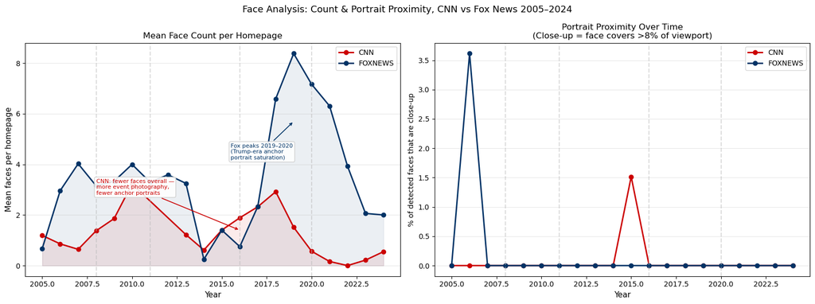

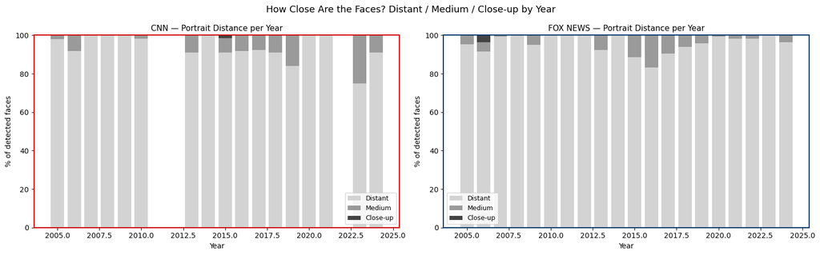

```python
# ── 10.1 Face count over time + portrait proximity ────────────────────────────
faces_by_year = face_counts.groupby(['outlet', 'year'])['face_count'].mean().reset_index()

close_by_year = (
    faces_only.assign(is_closeup=(faces_only['size_cat'] == 'Close-up'))
    .groupby(['outlet', 'year'])['is_closeup']
    .mean()
    .reset_index(name='closeup_pct')
)

fig, axes = plt.subplots(1, 2, figsize=(16, 6))

# Left: mean faces per page
ax = axes[0]
for outlet, color in [('cnn', '#cc0001'), ('foxnews', '#003366')]:
    d = faces_by_year[faces_by_year['outlet'] == outlet]
    ax.plot(d['year'], d['face_count'], marker='o', color=color,
            linewidth=2, label=outlet.upper())
    ax.fill_between(d['year'], d['face_count'], alpha=0.08, color=color)
for yr in [2008, 2011, 2016, 2020]:
    ax.axvline(yr, color='#bbb', linestyle='--', alpha=0.5)
ax.set_xlabel('Year', fontsize=11); ax.set_ylabel('Mean faces per homepage', fontsize=11)
ax.set_title('Mean Face Count per Homepage', fontsize=12)
ax.legend(fontsize=10); ax.grid(axis='y', alpha=0.3)
ax.annotate('Fox peaks 2019–2020\n(Trump-era anchor\nportrait saturation)',
            xy=(2019, 5.7), xytext=(2015.5, 4.2),
            fontsize=8, color='#003366',
            arrowprops=dict(arrowstyle='->', color='#003366', lw=1.2),
            bbox=dict(boxstyle='round,pad=0.3', fc='white', ec='#ccc', alpha=0.9))
ax.annotate('CNN: fewer faces overall —\nmore event photography,\nfewer anchor portraits',
            xy=(2016, 1.4), xytext=(2008, 2.8),
            fontsize=8, color='#cc0001',
            arrowprops=dict(arrowstyle='->', color='#cc0001', lw=1.2),
            bbox=dict(boxstyle='round,pad=0.3', fc='white', ec='#ccc', alpha=0.9))

# Right: % of detected faces that are close-up
ax = axes[1]
for outlet, color in [('cnn', '#cc0001'), ('foxnews', '#003366')]:
    d = close_by_year[close_by_year['outlet'] == outlet]
    ax.plot(d['year'], d['closeup_pct'] * 100, marker='o', color=color,
            linewidth=2, label=outlet.upper())
for yr in [2008, 2011, 2016, 2020]:
    ax.axvline(yr, color='#bbb', linestyle='--', alpha=0.5)
ax.set_xlabel('Year', fontsize=11)
ax.set_ylabel('% of detected faces that are close-up', fontsize=10)
ax.set_title('Portrait Proximity Over Time\n(Close-up = face covers >8% of viewport)', fontsize=12)
ax.legend(fontsize=10); ax.grid(axis='y', alpha=0.3)

plt.suptitle('Face Analysis: Count & Portrait Proximity, CNN vs Fox News 2005–2024', fontsize=13)
plt.tight_layout()
plt.savefig(OUTPUT_DIR / 'face_count_proximity.png', dpi=150)
plt.show()

# ── Portrait size breakdown per outlet per year (stacked bars) ────────────────
fig, axes = plt.subplots(1, 2, figsize=(16, 5))
cats = ['Distant', 'Medium', 'Close-up']
cat_colors = ['#cccccc', '#888888', '#222222']

for ax_i, (outlet, label) in enumerate([('cnn', 'CNN'), ('foxnews', 'FOX NEWS')]):
    od = faces_only[faces_only['outlet'] == outlet]
    year_size = (od.groupby(['year', 'size_cat']).size()
                   .unstack(fill_value=0)
                   .reindex(columns=cats, fill_value=0))
    totals = year_size.sum(axis=1).replace(0, 1)
    year_pct = year_size.div(totals, axis=0) * 100
    ax = axes[ax_i]
    bottom = np.zeros(len(year_pct))
    for cat, col in zip(cats, cat_colors):
        if cat in year_pct.columns:
            ax.bar(year_pct.index, year_pct[cat], bottom=bottom, color=col, label=cat, alpha=0.85)
            bottom += year_pct[cat].fillna(0).values
    ax.set_title(f'{label} — Portrait Distance per Year', fontsize=11)
    ax.set_xlabel('Year'); ax.set_ylabel('% of detected faces')
    ax.legend(fontsize=9); ax.set_ylim(0, 100)
    c = '#cc0001' if outlet == 'cnn' else '#003366'
    for spine in ax.spines.values():
        spine.set_edgecolor(c); spine.set_linewidth(1.5)

plt.suptitle('How Close Are the Faces? Distant / Medium / Close-up by Year', fontsize=13)
plt.tight_layout()
plt.savefig(OUTPUT_DIR / 'face_proximity_breakdown.png', dpi=150)
plt.show()
```

[figure not shown]

```python
# ── 10.2 Face crop gallery — one row per size category ────────────────────────
fig, axes = plt.subplots(3, 8, figsize=(20, 9))

for row_idx, cat in enumerate(['Distant', 'Medium', 'Close-up']):
    cat_faces = faces_only[faces_only['size_cat'] == cat]
    sample = cat_faces.sample(min(8, len(cat_faces)), random_state=row_idx)
    for col_idx in range(8):
        ax = axes[row_idx, col_idx]
        if col_idx < len(sample):
            r = sample.iloc[col_idx]
            try:
                img = Image.open(r['filepath']).convert('RGB')
                x, y, w, h = int(r['face_x']), int(r['face_y']), int(r['face_w']), int(r['face_h'])
                iw, ih = int(r['img_w']), int(r['img_h'])
                # Add 30% padding around the detected box
                pad = 0.35
                x1 = max(0, int(x - w * pad)); y1 = max(0, int(y - h * pad))
                x2 = min(iw, int(x + w * (1 + pad))); y2 = min(ih, int(y + h * (1 + pad)))
                crop = img.crop((x1, y1, x2, y2))
                ax.imshow(crop)
                color = '#cc0001' if r['outlet'] == 'cnn' else '#003366'
                ax.set_title(f"{r['outlet'].upper()} {r['year']}", fontsize=6, color=color)
            except Exception:
                pass
        ax.axis('off')
        if col_idx == 0:
            ax.set_ylabel(cat, fontsize=11, fontweight='bold',
                          rotation=0, ha='right', va='center', labelpad=50)

plt.suptitle('Face Crop Samples by Portrait Distance Category\n'
             'Distant = small thumbnail face  |  Medium = half-frame  |  Close-up = fills viewport',
             fontsize=12, y=1.02)
plt.tight_layout()
plt.savefig(OUTPUT_DIR / 'face_crops_by_size.png', dpi=150, bbox_inches='tight')
plt.show()
```

### 10.3 Recurring Face Clusters

From Claude: This is not facial recognition; ResNet was not trained for identity. But faces that look visually similar (same person, same lighting, similar pose) tend to cluster together, so the largest clusters often correspond to recurring individuals.

> **Run this in Terminal first** (face embedding + UMAP takes ~5 min):

> ```
> conda activate image-analysis
> cd "/Users/sophiacallahan/Desktop/spring_2026/cultural_analytics/week 12"
> python wayback_output/run_umap.py
> ```

> The script will print `Section 4` progress and save `face_embeddings.npy`, `face_umap.npy`, `face_meta.csv`.

```python
import gc
import umap as umap_lib
from sklearn.preprocessing import StandardScaler
from sklearn.decomposition import PCA
from sklearn.cluster import KMeans
import torchvision.models as models
import torchvision.transforms as transforms

FACE_EMB_CACHE  = OUTPUT_DIR / 'face_embeddings.npy'
FACE_UMAP_CACHE = OUTPUT_DIR / 'face_umap.npy'
FACE_META_CSV   = OUTPUT_DIR / 'face_meta.csv'

# ── Step 1: Embed face crops ──────────────────────────────────────────────────
if FACE_EMB_CACHE.exists() and FACE_META_CSV.exists():
    face_embeddings = np.load(str(FACE_EMB_CACHE))
    face_meta       = pd.read_csv(str(FACE_META_CSV))
    print(f'Loaded cached face embeddings: {face_embeddings.shape}')
else:
    print(f'Embedding {len(faces_only)} face crops with ResNet-50 (~3-6 min)...')
    resnet_face = models.resnet50(weights=models.ResNet50_Weights.IMAGENET1K_V2)
    resnet_face.eval()
    face_ext = torch.nn.Sequential(*list(resnet_face.children())[:-1])
    face_ext.to(DEVICE); face_ext.eval()

    preprocess_face = transforms.Compose([
        transforms.Resize(128),
        transforms.CenterCrop(112),
        transforms.ToTensor(),
        transforms.Normalize(mean=[0.485, 0.456, 0.406], std=[0.229, 0.224, 0.225]),
    ])

    embeddings_list, valid_idx_list = [], []
    with torch.no_grad():
        for i, row in tqdm(faces_only.iterrows(), total=len(faces_only), desc='Face embeddings'):
            try:
                img = Image.open(row['filepath']).convert('RGB')
                x, y, w, h = int(row['face_x']), int(row['face_y']), int(row['face_w']), int(row['face_h'])
                iw, ih = int(row['img_w']), int(row['img_h'])
                pad = 0.35
                x1 = max(0, int(x - w * pad)); y1 = max(0, int(y - h * pad))
                x2 = min(iw, int(x + w * (1 + pad))); y2 = min(ih, int(y + h * (1 + pad)))
                if x2 <= x1 or y2 <= y1:
                    continue
                tensor = preprocess_face(img.crop((x1, y1, x2, y2))).unsqueeze(0).to(DEVICE)
                embeddings_list.append(face_ext(tensor).squeeze().cpu().numpy())
                valid_idx_list.append(i)
            except Exception:
                pass

    del face_ext, resnet_face; gc.collect()
    if DEVICE.type == 'mps':    torch.mps.empty_cache()
    elif DEVICE.type == 'cuda': torch.cuda.empty_cache()

    face_embeddings = np.array(embeddings_list, dtype=np.float32)
    face_meta       = faces_only.iloc[valid_idx_list].reset_index(drop=True)
    np.save(str(FACE_EMB_CACHE), face_embeddings)
    face_meta.to_csv(str(FACE_META_CSV), index=False)
    print(f'Saved {face_embeddings.shape[0]} face embeddings')

# ── Step 2: PCA + UMAP on face embeddings ────────────────────────────────────
if FACE_UMAP_CACHE.exists():
    face_umap_emb = np.load(str(FACE_UMAP_CACHE))
    print(f'Loaded cached face UMAP: {face_umap_emb.shape}')
else:
    print('PCA on face embeddings...')
    emb_scaled = StandardScaler().fit_transform(face_embeddings).astype(np.float32)
    emb_pca    = PCA(n_components=min(50, face_embeddings.shape[0] - 1),
                     random_state=42).fit_transform(emb_scaled).astype(np.float32)
    print(f'UMAP on {face_embeddings.shape[0]} face crops...')
    face_umap_emb = umap_lib.UMAP(
        n_neighbors=10, min_dist=0.05, n_components=2,
        metric='cosine', random_state=42, n_jobs=1, low_memory=True
    ).fit_transform(emb_pca)
    np.save(str(FACE_UMAP_CACHE), face_umap_emb)
    print(f'Saved face UMAP: {face_umap_emb.shape}')

# ── Step 3: Cluster + visualize ───────────────────────────────────────────────
K_FACES = 40
face_meta['cluster'] = KMeans(
    n_clusters=K_FACES, random_state=42, n_init=5,
    algorithm='lloyd', max_iter=100
).fit_predict(face_umap_emb)

fig = px.scatter(
    face_meta,
    x=face_umap_emb[:, 0], y=face_umap_emb[:, 1],
    color='outlet',
    color_discrete_map={'cnn': '#cc0001', 'foxnews': '#003366'},
    hover_data=['year', 'filename'],
    title='UMAP of Individual Face Crops — Each Dot = One Detected Face',
    labels={'x': 'UMAP 1', 'y': 'UMAP 2'},
    opacity=0.55
)
fig.update_traces(marker=dict(size=4))
fig.update_layout(height=550, width=900)
fig.add_annotation(
    x=0.5, y=-0.10, xref='paper', yref='paper',
    text="Proximity = visual similarity of face crop. "
         "<b>Tight clusters = a person appearing many times.</b> "
         "Clusters with both colors = that face appeared on both outlets.",
    showarrow=False, font=dict(size=10, color='#555'), align='center'
)
fig.show(renderer='notebook')

top_clusters = face_meta['cluster'].value_counts().head(12).index.tolist()
CROP_SIZE = 80

fig, big_axes = plt.subplots(4, 3, figsize=(18, 24))
for ax_i, cluster_id in enumerate(top_clusters):
    ax = big_axes[ax_i // 3, ax_i % 3]
    cluster_faces = face_meta[face_meta['cluster'] == cluster_id]
    outlet_mix = cluster_faces['outlet'].value_counts().to_dict()
    samples = cluster_faces.sample(min(6, len(cluster_faces)), random_state=42)

    composite = Image.new('RGB', (CROP_SIZE * 3, CROP_SIZE * 2), (230, 230, 230))
    for crop_i, (_, fr) in enumerate(samples.iterrows()):
        if crop_i >= 6: break
        try:
            img = Image.open(fr['filepath']).convert('RGB')
            x, y, w, h = int(fr['face_x']), int(fr['face_y']), int(fr['face_w']), int(fr['face_h'])
            iw, ih = int(fr['img_w']), int(fr['img_h'])
            pad = 0.35
            x1 = max(0, int(x - w * pad)); y1 = max(0, int(y - h * pad))
            x2 = min(iw, int(x + w * (1 + pad))); y2 = min(ih, int(y + h * (1 + pad)))
            if x2 > x1 and y2 > y1:
                crop = img.crop((x1, y1, x2, y2)).resize((CROP_SIZE, CROP_SIZE))
                composite.paste(crop, ((crop_i % 3) * CROP_SIZE, (crop_i // 3) * CROP_SIZE))
        except Exception:
            pass

    ax.imshow(composite)
    cnn_n = outlet_mix.get('cnn', 0)
    fox_n = outlet_mix.get('foxnews', 0)
    cross = '  * both outlets' if cnn_n > 0 and fox_n > 0 else ''
    title_color = '#555' if cross else ('#cc0001' if fox_n == 0 else '#003366')
    ax.set_title(
        f'Cluster {cluster_id}  ({len(cluster_faces)} appearances){cross}\n'
        f'CNN: {cnn_n}    Fox: {fox_n}',
        fontsize=8.5, color=title_color
    )
    ax.axis('off')

plt.suptitle(f'Top 12 Most Frequent Face Clusters  (K={K_FACES} total)\n'
             'Both outlets = face appeared on CNN and Fox  |  each tile = 6 sample crops',
             fontsize=13)
plt.tight_layout()
plt.savefig(OUTPUT_DIR / 'face_clusters.png', dpi=150)
plt.show()

print('\nTop 15 clusters by size:')
print(face_meta.groupby('cluster')[['outlet', 'year']]
      .agg(total=('outlet', 'count'),
           cnn=('outlet', lambda x: (x == 'cnn').sum()),
           fox=('outlet', lambda x: (x == 'foxnews').sum()),
           years=('year', lambda x: f"{x.min()}-{x.max()}"))
      .sort_values('total', ascending=False).head(15).to_string())
```

[output not shown]

## 11. Results and Discussion

### Method

The pipeline follows Workshop 3: ResNet-50 (pretrained on ImageNet) → StandardScaler → PCA (2,048 → 50 dimensions) → UMAP (cosine, n_neighbors=15, min_dist=0.1) → KMeans (K=8). Temporal analysis uses centroid distances in both UMAP and feature space. Color and face analysis run independently on the filtered screenshots.

A note on terminology: "CNN features" in Section 8 refers to *Convolutional Neural Network* features (the ResNet-50 model), not the news outlet.

A limitation: ResNet-50 was trained on natural photographs, not web pages. It may respond more strongly to photographic content (hero images, article photos) than to typographic or layout differences. Color histograms in Section 8 provide a useful baseline for separating palette-driven effects.

### Future Directions

1. **CLIP features** — CLIP encodes visual and textual content jointly. For web screenshots containing both images and text, CLIP might separate outlets more cleanly than ResNet-50.
2. **OCR + text analysis** — extracting headline text from screenshots would allow questions like: do CNN and Fox use visually similar layouts but different text registers?
3. **Expand to other outlets** — adding MSNBC, BBC, NYTimes, and Breitbart would allow a fuller mapping of the news homepage design space.
4. **Event-triggered sampling** — sampling densely around major news events to see how homepages respond to breaking news.

## Appendix

### Wayback Machine CDX API

| Parameter | Value used | Notes |
| --- | --- | --- |
| `url` | `http://www.cnn.com/` | Exact homepage match |
| `matchType` | `exact` | No subdomain/path variants |
| `filter` | `statuscode:200` | Exclude redirects and errors |
| `collapse` | `timestamp:8` | At most one snapshot per calendar day |
| `limit` | 500 | Max candidates per year before sampling |

### Wayback URL Format

```
https://web.archive.org/web/{timestamp}if_/http://www.cnn.com/
```

The `if_` modifier suppresses the Wayback Machine toolbar, so screenshots show only the archived page.

### UMAP Parameters

| Parameter | Value | Notes |
| --- | --- | --- |
| `n_neighbors` | 15 | Higher = more global structure |
| `min_dist` | 0.1 | Lower = tighter clusters |
| `metric` | cosine | Better than euclidean for CNN features |

### Rate Limiting

The notebook uses a 2.5-second delay between Playwright requests. The Internet Archive requests polite crawling; do not reduce this below 1 second.